# Preprocessing

Jessy Min

2018년 3월 5일

## 1. Setting

```r
library(rvest)
library(stringr)
library(dplyr)
```

```r
library(ggplot2)
```

## 2. Scrap Data

데이터는 Sur La Table 웹사이트에서 수집했으며, 카테고리별 URL은 하드코딩하였다.

```r
base_url1 <- "https://www.surlatable.com/category/TCA-"
base_url2 <- "&No=0&Nrpp=200&pCat=CAT-351560"
category_list <- c("257800/Blenders?N=17841",
                   "257802/Food+Processors?N=17842",
                   "333580/Hand+Mixers?N=17843",
                   "333582/Immersion+Blenders?N=17844",
                   "257820/Toasters+&+Ovens?N=17847",
                   "257818/Multi+Cookers+&+Slow+Cookers?N=17857",
                   "258207/Coffee+Makers?N=18011",
                   "258225/Espresso+Machines?N=18012")
```

수집한 데이터에서 Item name의 첫머리에 포함된 브랜드 이름을 추출했다.

```r
# Scrap data from website
df <- data.frame()

for (i in 1:length(category_list)) {
        category <- category_list[i]
        raw_data <- read_html(paste0(base_url1, category, base_url2))

        # Get Item name
        name <- html_nodes(raw_data, css='.name') %>% html_text() %>%
                str_split(" ", 2)

        # Extract Brand name
        brand = lapply(name, function(x) {x[c(1)]}) %>% unlist()
        category_data <- data.frame("brand" = brand)

        # Extract Product name
        product_name <- lapply(name, function(x) {x[c(2)]}) %>% unlist()
        category_data$product_name <- product_name

        # Extract Price
        price <- html_nodes(raw_data, css='.product-display-price') %>% html_text()
        price <- substring(price, 2)
        category_data$price <- price

        # Set Category
        category_data$category <- category

       # Merge dataframe
        df <- rbind(df, category_data)
}

rm(base_url1, base_url2, category, category_list, category_data, i, name, brand, price, product_name)
```

## 3. Cleaning Data

- Category : 스크래핑에 쓰인 url로부터 제품 카테고리 추출
- Price : 세일 중인 제품의 경우 범위로 제시되어, 최저가만 추출함
- Brand : 브랜드명+제품명 공식에 맞지 않아 잘못 추출된 경우 수정

```r
# Clean Category name
df$category <- str_sub(df$category, 8) %>%
        str_sub(end = -9) %>%
        str_replace_all("\\+", " ")

# Clean Price
df$price <- str_sub(df$price, end = 7) %>% #최저가 추출
        str_replace_all(",", "") %>%
        str_replace_all("-", "")

df$price <- as.numeric(df$price)

# Clean Brand name
df$brand <- df$brand %>% str_replace("®", "")

unique(df$brand)
```

```
##  [1] "Vitamix"     "Breville"    "KitchenAid"  "Cuisinart"   "Wolf"
##  [6] "Omega"       "Braun"       "All-Clad"    "Kenwood"     "Dualit"
## [11] "Krups"       "De’Longhi"  "Panasonic"   "SMEG"        "The"
## [16] "Fagor"       "Instant"     "Sous"        "Oliso"       "Brød"
## [21] "OXO"         "Anova"       "Joule"       "Capresso"    "Technivorm"
## [26] "Chemex"      "Nespresso"   "Sur"         "Cold"        "JURA"
## [31] "Gaggia"      "Jura"        "Bonavita"    "Motif"       "Miele"
## [36] "illy"        "Francis"     "Espressione" "Illy"
```

```r
filter(df, brand == 'The')
```

```
##   brand                     product_name  price         category
## 1   The Studio by Dualit 2-Slice Toaster  99.95 Toasters & Ovens
## 2   The Studio by Dualit 4-Slice Toaster 159.95 Toasters & Ovens
```

```r
df$brand[df$brand == 'The'] <- 'Dualit'

# Save backup data
date <- Sys.Date()
write.csv(df, file=paste0("df_backup_",date), row.names=F)
```

### 중복되는 데이터 제거

이커머스에는 동일한 제품이 여러 카테고리에 등록된 경우가 있다. 카테고리 별로 웹스크래핑 함에 따라 중복 수집된 제품을 확인하고, 한쪽을 제거하였다.

```r
length(df$product_name) - length(unique(df$product_name)) #제품 중복여부 확인
```

```
## [1] 43
```

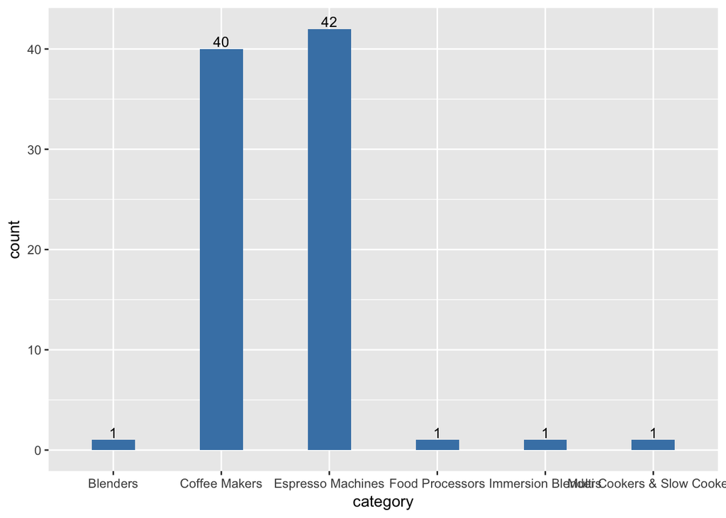

```r
df <- group_by(df, product_name) %>%
        mutate(overlap = n()) #제품 개수 카운트
df <- data.frame(df)

df_overlap <- filter(df, overlap == 2) #중복된 제품 별도 추출
ggplot(df_overlap, aes(category)) +
        geom_bar(stat="count", fill="steelblue", width=0.4) +
        geom_text(stat="count", aes(label=..count..), vjust=-0.2, size=3.5)
```

```r
table(df_overlap$category)
```

```
##
##                     Blenders                Coffee Makers
##                            1                           40
##            Espresso Machines              Food Processors
##                           42                            1
##           Immersion Blenders Multi Cookers & Slow Cookers
##                            1                            1
```

중복되는 데이터는 대부분 커피메이커/에스프레소 머신 2개 카테고리에 분포하고 있다. 제품의 특성과 높은 가격대를 고려하여, Coffee Maker 카테고리의 데이터를 삭제하였다. 그 외 카테고리의 제품은, 브랜드별로 라인업의 범위를 파악하려는 분석 목적을 고려하여 가급적 다양한 카테고리에 분포되도록 하드코딩하였다.

```r
# 제거할 제품 리스트만 남기기
remove_list <- filter(df_overlap, category != "Espresso Machines")
remove_list <- remove_list[-(remove_list$category == "Food Processors"),]

# 전체 데이터셋에서 제거
df <- setdiff(df, remove_list)
df <- df[,-5]
rm(df_overlap, remove_list)
```

## Filter Data

### 분석대상 브랜드 필터링

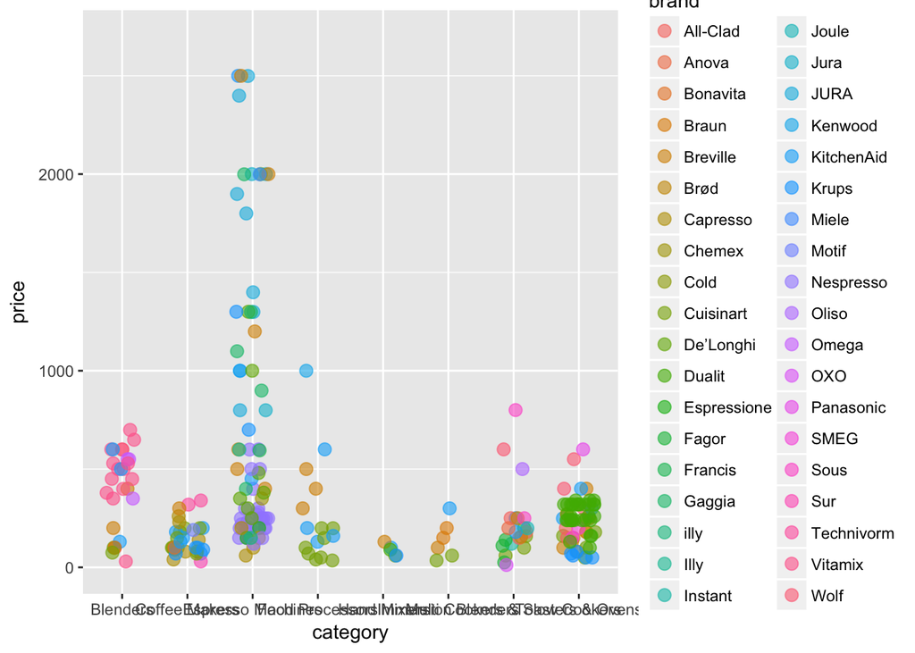

```r
# 현재상태 파악
ggplot(df, aes(category, price, col=brand)) + geom_jitter(width=0.25, alpha=0.6, size=3) +
        coord_cartesian(ylim = c(0,2700))
```

```r
length(unique(df$brand))
```

```
## [1] 38
```

```r
brand_list = c("Breville", "Vitamix", "Kitchenaid", "All-Clad","Braun", "Cuisinart",
               "De’Longhi","Dualit","JURA","Kenwood","Miele","Nespresso","SMEG",
               "Technivorm","Wolf")

over_5 <- df %>% group_by(brand) %>%
        summarise(num_product = length(product_name)) %>%
        filter(num_product >= 5)

brand_list <- union(brand_list, unlist(over_5[,1]))

df$brand <- as.character(df$brand)
df <- filter(df, brand %in% brand_list)

rm(brand_list, over_5)
```

### 브랜드별 본사 지역 정보 추가

```r
df <- mutate(df, region = case_when(
                df$brand %in% c("All-Clad","Capresso","Cuisinart","KitchenAid","Omega",
                            "Vitamix","Wolf") ~ "US",
                df$brand %in% c("Braun","De’Longhi","Dualit","Gaggia","JURA","Kenwood",
                             "Krups","Miele","Nespresso","Smeg","Technivorm") ~ "Europe",
                df$brand == "Breville" ~ "Australia"
                )
        )
```

### Factorize some variables

```r
df$brand <- as.factor(df$brand)
df$category <- factor(df$category,
                         c("Blenders","Immersion Blenders","Hand Mixers",
                           "Food Processors","Coffee Makers","Espresso Machines",
                           "Multi Cookers & Slow Cookers","Toasters & Ovens"))
df$region <- as.factor(df$region)
```

### Save File

```r
date <- Sys.Date()
write.csv(df, file=paste0("Small_Appliance_", date), row.names=F)
```